# Project 1

Diana Garcia

2022-07-21

## Introduction

It is now possible to collect a large amount of data about personal movement using activity monitoring devices such as a Fitbit, Nike Fuelband, or Jawbone Up. These type of devices are part of the “quantified self” movement - a group of enthusiasts who take measurements about themselves regularly to improve their health, to find patterns in their behavior, or because they are tech geeks. But these data remain under-utilized both because the raw data are hard to obtain and there is a lack of statistical methods and software for processing and interpreting the data.

This assignment makes use of data from a personal activity monitoring device. This device collects data at 5 minute intervals through out the day. The data consists of two months of data from an anonymous individual collected during the months of October and November, 2012 and include the number of steps taken in 5 minute intervals each day.

The data for this assignment can be downloaded from the course web site:

- Dataset: [Activity monitoring data](https://d396qusza40orc.cloudfront.net/repdata%2Fdata%2Factivity.zip)

The variables included in this dataset are:

steps: Number of steps taking in a 5-minute interval (missing values are coded as NA)  
date: The date on which the measurement was taken in YYYY-MM-DD format  
interval: Identifier for the 5-minute interval in which measurement was taken  
The dataset is stored in a comma-separated-value (CSV) file and there are a total of 17,568 observations in this dataset.

## Loading and preprocessing the data

```r
fileUrl <- "https://d396qusza40orc.cloudfront.net/repdata%2Fdata%2Factivity.zip"
download.file(fileUrl, destfile = paste0(getwd(), '/repdata%2Fdata%2Factivity.zip'), method = "curl")
unzip("repdata%2Fdata%2Factivity.zip",exdir = "data")
activity <- data.table::fread(input = "data/activity.csv")
activity$date=as.Date(activity$date)
```

## What is mean total number of steps taken per day?

### Total number of steps taken per day

```r
library(plyr)
byDay=ddply(activity,"date",summarize, sum=sum(steps))
```

### Make an histogram of the total number of steps taken each day

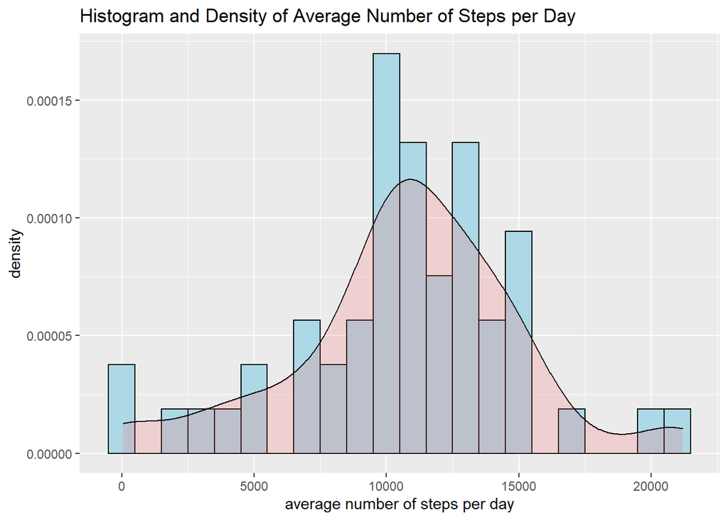

```r
library(ggplot2)
ggplot(byDay, aes(x=sum))+
        geom_histogram(aes(y=..density..),binwidth=1000,
        colour="black", fill="lightblue") +
        geom_density(alpha=.2, fill="#FF6666")+
        labs(title="Histogram and Density of Average Number of Steps per Day")+
        labs(x="average number of steps per day",y="density")
```

### Calculate and report the mean and the median

```r
meanDay=round(mean(byDay$sum,na.rm=TRUE))
medianDay=median(byDay$sum,na.rm=TRUE)
print(meanDay)
```

```
## [1] 10766
```

```r
print(medianDay)
```

```
## [1] 10765
```

## What is the average daily activity pattern?

### Make a time series plot of the 5 min interval and the average number of steps taken, averaged across all days

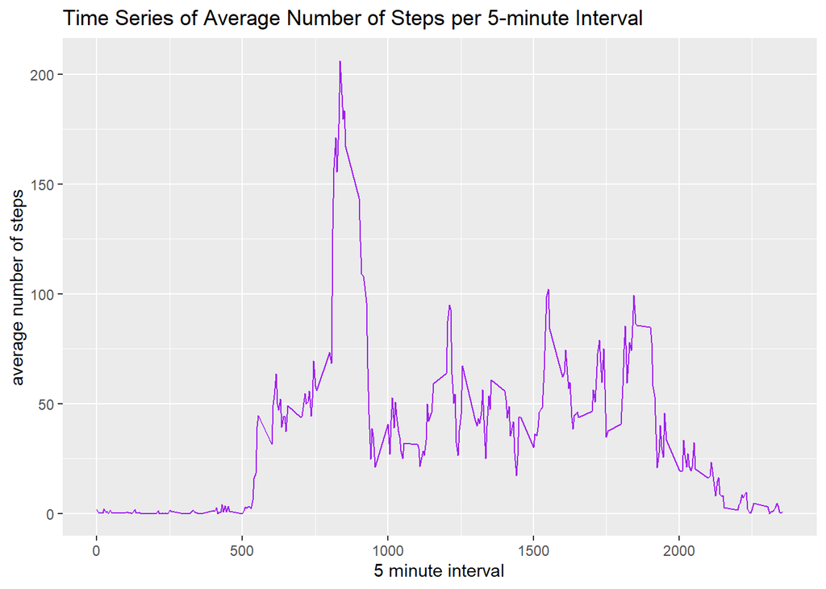

```r
byInt=ddply(activity,"interval",summarize, avg=mean(steps,na.rm=TRUE))
ggplot(byInt, aes(x = interval, y = avg, group = 1))+
         geom_line(colour="purple")+
        labs(title="Time Series of Average Number of Steps per 5-minute Interval")+
        labs(x="5 minute interval",y="average number of steps")
```

### Which 5 min interval contains the maximum number of steps?

```r
which.max(byInt[,2])
```

```
## [1] 104
```

```r
maxInt=round(byInt[104,])
byIntSort=byInt[order(byInt[,2],decreasing=TRUE),]
```

The interval which contains the maximum average number of steps taken is interval 835 for a maximum average of 206 number of steps.

## Imputing missing values

1. Calculate and report the total number of missing values in the dataset

```r
miss=sum(is.na(activity))
n=nrow(activity)
prop=round(sum(is.na(activity))/nrow(activity)*100,1)
```

The total number of missing values in the dataset is 2304. To fill in the missing data I will replace the missing value with the mean of the corresponding 5-minute interval for that missing value. This is done with the packages ‘plyr’ and ‘Hmisc’.

2. Devise a strategy for filling in all of the missing values in the dataset. The strategy does not need to be sophisticated. For example, you could use the mean/median for that day, or the mean for that 5-minute interval, etc.

```r
library(Hmisc)
activity.imputed = ddply(activity, "interval", mutate,
                         imputed.steps = impute(steps, mean))
act.imp.order=activity.imputed[order(activity.imputed[,2],decreasing=FALSE),]
activity.imp=act.imp.order[,c(4,2,3)]
activity.imp$imputed.steps=as.integer(activity.imp$imputed.steps)
detach("package:Hmisc")
```

4. Make a histogram of the total number of steps taken each day and calculate and report the mean and median total number of steps taken per day. Do these values differ from the estimates from the first part of the assignment? What is the impact of imputing missing data on the estimates of the total daily number of steps?

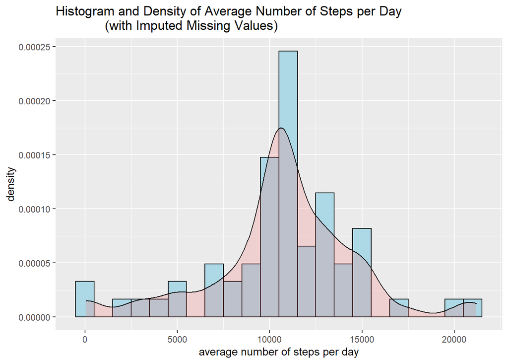

```r
byDay.imp=ddply(activity.imp,"date",summarize, sum=sum(imputed.steps))
ggplot(byDay.imp, aes(x=sum)) +theme_set(theme_bw())+
        geom_histogram(aes(y=..density..),binwidth=1000,
        colour="black", fill="lightblue") +
        geom_density(alpha=.2, fill="#FF6666")+
        labs(title="Histogram and Density of Average Number of Steps per Day
             (with Imputed Missing Values)")+
        labs(x="average number of steps per day",y="density")
```

```r
mean.imp=round(mean(byDay.imp$sum,na.rm=TRUE))
median.imp=median(byDay.imp$sum,na.rm=TRUE)
print(mean.imp)
```

```
## [1] 10750
```

```r
print(median.imp)
```

```
## [1] 10641
```

The mean and median number of steps per day from the new dataset are 10750 and 10641 respectively. These values do differ from the estimates from the original dataset by 16 and 124 for the means and medians, respectively. From the histogram it appears that replacing the missing values with the means of that 5-minute interval have concentrated the average total number of steps per day around 10000 steps.

## Are there differences in activity patterns between weekdays and weekends?